# SVM Regression

By Spencer Gray & Michael Stinnett

2022-10-23

Data Source: [Austin, TX House Listings](https://www.kaggle.com/datasets/ericpierce/austinhousingprices)

## Load Packages

```r
library(e1071)
```

## Load Data

```r
df <- read.csv("austinHousingData.csv")
```

## Clean Data

Ran linear regression once on the data prior to see what columns are important predictors.

```r
df <- df[, c(4, 10, 12, 14, 16, 18, 19, 20, 23, 28, 31, 35, 39, 40, 42, 44, 45, 46)]
df[sapply(df, is.character)] <- lapply(df[sapply(df, is.character)],
                                       as.factor)
df$zipcode <- as.factor(df$zipcode)
```

## Divide into train/test/validate

```r
set.seed(1234)
spec <- c(train=.6, test=.2, validate=.2)
i <- sample(cut(1:nrow(df),
                nrow(df)*cumsum(c(0,spec)), labels=names(spec)))
train <- df[i=="train",]
test <- df[i=="test",]
vald <- df[i=="validate",]
```

## Data Exploration

```r
summary(train)
```

```
##     zipcode     hasAssociation hasGarage      hasSpa
##  78748  : 710   False:4358     False:4085   False:8380
##  78745  : 630   True :4744     True :5017   True : 722
##  78749  : 452
##  78704  : 431
##  78739  : 380
##  78737  : 366
##  (Other):6133
##                homeType      yearBuilt     latestPrice       numPriceChanges
##  Single Family     :8523   Min.   :1906   Min.   :    5500   Min.   : 1.000
##  Condo             : 305   1st Qu.:1974   1st Qu.:  305000   1st Qu.: 1.000
##  Townhouse         :  99   Median :1993   Median :  400000   Median : 2.000
##  Multiple Occupancy:  64   Mean   :1988   Mean   :  517977   Mean   : 3.051
##  Vacant Land       :  48   3rd Qu.:2006   3rd Qu.:  575000   3rd Qu.: 4.000
##  Apartment         :  23   Max.   :2020   Max.   :13500000   Max.   :23.000
##  (Other)           :  40
##  latest_saleyear numOfParkingFeatures numOfWaterfrontFeatures livingAreaSqFt
##  Min.   :2018    Min.   :0.000        Min.   :0.000000        Min.   :   306
##  1st Qu.:2018    1st Qu.:1.000        1st Qu.:0.000000        1st Qu.:  1485
##  Median :2019    Median :2.000        Median :0.000000        Median :  1974
##  Mean   :2019    Mean   :1.717        Mean   :0.003186        Mean   :  2217
##  3rd Qu.:2020    3rd Qu.:2.000        3rd Qu.:0.000000        3rd Qu.:  2674
##  Max.   :2021    Max.   :6.000        Max.   :2.000000        Max.   :109292
##
##  numOfHighSchools avgSchoolDistance avgSchoolSize  numOfBathrooms
##  Min.   :0.0000   Min.   :0.200     Min.   : 396   Min.   : 0.000
##  1st Qu.:1.0000   1st Qu.:1.100     1st Qu.: 983   1st Qu.: 2.000
##  Median :1.0000   Median :1.533     Median :1281   Median : 3.000
##  Mean   :0.9793   Mean   :1.836     Mean   :1237   Mean   : 2.682
##  3rd Qu.:1.0000   3rd Qu.:2.267     3rd Qu.:1494   3rd Qu.: 3.000
##  Max.   :2.0000   Max.   :9.000     Max.   :1913   Max.   :13.000
##
##  numOfBedrooms     numOfStories
##  Min.   : 0.000   Min.   :1.000
##  1st Qu.: 3.000   1st Qu.:1.000
##  Median : 3.000   Median :1.000
##  Mean   : 3.437   Mean   :1.463
##  3rd Qu.: 4.000   3rd Qu.:2.000
##  Max.   :10.000   Max.   :4.000
##
```

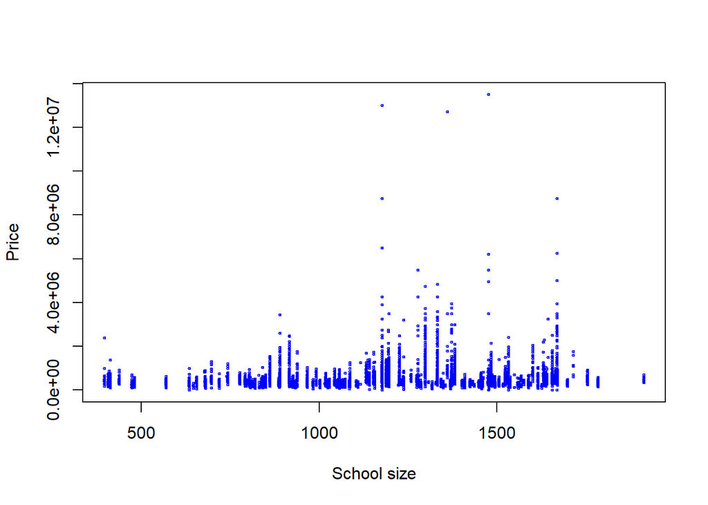

```r
plot(train$avgSchoolSize, train$latestPrice, cex = 0.35, col="blue", xlab="School size", ylab="Price")
```

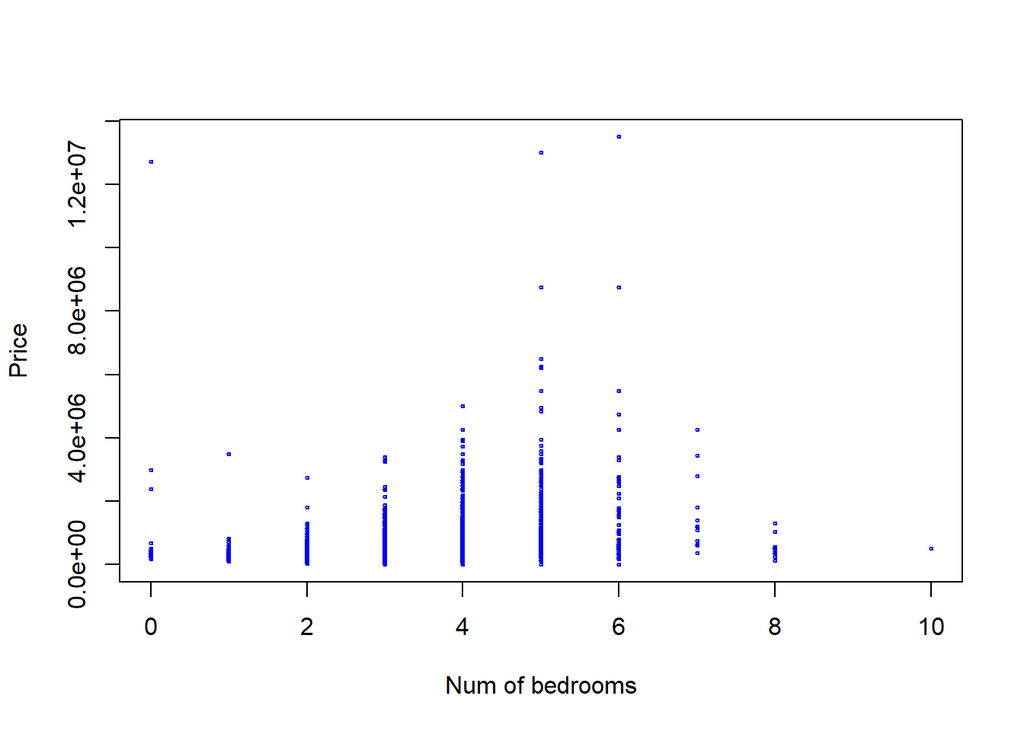

```r
plot(train$numOfBedrooms, train$latestPrice, cex = 0.35, col="blue", xlab="Num of bedrooms", ylab="Price")
```

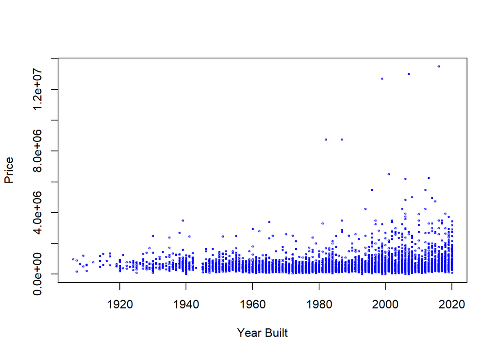

```r
plot(train$yearBuilt, train$latestPrice, cex = 0.35, col="blue", xlab="Year Built", ylab="Price")
```

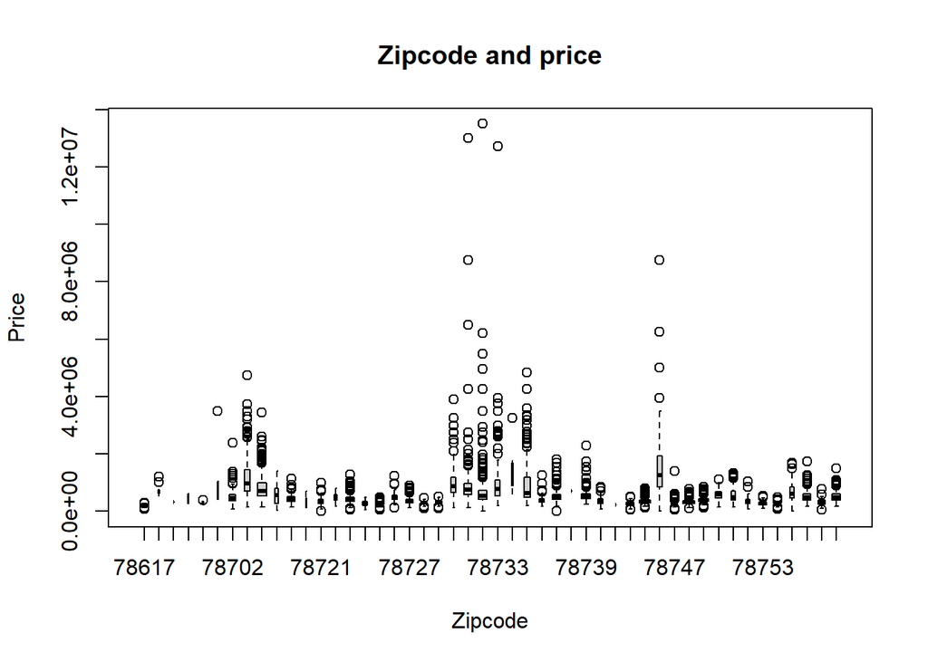

```r
boxplot(train$latestPrice~train$zipcode, varwidth=TRUE, notch=FALSE,
main="Zipcode and price", xlab="Zipcode", ylab="Price")
```

### Try linear regression

```r
lm1 <- lm(latestPrice~., data=train)
pred <- predict(lm1, newdata=test)
cor_lm1 <- cor(pred, test$latestPrice)
mse_lm1 <- mean((pred-test$latestPrice)^2)
summary(lm1)
```

```
##
## Call:
## lm(formula = latestPrice ~ ., data = train)
##
## Residuals:
##      Min       1Q   Median       3Q      Max
## -5636169  -104434    -9590    80954 11898721
##
## Coefficients:
##                                 Estimate Std. Error t value Pr(>|t|)
## (Intercept)                   -6.371e+07  9.766e+06  -6.524 7.23e-11 ***
## zipcode78619                  -1.901e+05  1.275e+05  -1.491 0.135885
## zipcode78652                   1.341e+05  3.475e+05   0.386 0.699545
## zipcode78653                  -6.890e+05  2.504e+05  -2.751 0.005949 **
## zipcode78660                   4.115e+04  8.648e+04   0.476 0.634257
## zipcode78701                   1.015e+06  1.624e+05   6.249 4.31e-10 ***
## zipcode78702                   3.154e+05  5.639e+04   5.593 2.30e-08 ***
## zipcode78703                   7.891e+05  5.500e+04  14.349  < 2e-16 ***
## zipcode78704                   5.582e+05  5.188e+04  10.760  < 2e-16 ***
## zipcode78705                   4.490e+05  7.237e+04   6.204 5.76e-10 ***
## zipcode78717                   1.325e+04  5.127e+04   0.258 0.796145
## zipcode78719                  -3.438e+05  2.066e+05  -1.664 0.096213 .
## zipcode78721                   1.707e+05  6.000e+04   2.845 0.004454 **
## zipcode78722                   3.676e+05  6.743e+04   5.451 5.13e-08 ***
## zipcode78723                   1.839e+05  5.402e+04   3.404 0.000668 ***
## zipcode78724                  -3.243e+04  5.894e+04  -0.550 0.582196
## zipcode78725                  -7.680e+03  6.010e+04  -0.128 0.898327
## zipcode78726                   5.822e+04  5.799e+04   1.004 0.315403
## zipcode78727                   9.670e+04  5.252e+04   1.841 0.065605 .
## zipcode78728                   1.343e+04  5.564e+04   0.241 0.809212
## zipcode78729                   2.509e+04  5.410e+04   0.464 0.642851
## zipcode78730                   3.260e+05  5.661e+04   5.758 8.78e-09 ***
## zipcode78731                   4.874e+05  5.200e+04   9.373  < 2e-16 ***
## zipcode78732                   1.842e+05  5.106e+04   3.608 0.000310 ***
## zipcode78733                   4.397e+05  6.398e+04   6.873 6.71e-12 ***
## zipcode78734                   7.763e+05  1.324e+05   5.864 4.68e-09 ***
## zipcode78735                   2.974e+05  5.573e+04   5.336 9.72e-08 ***
## zipcode78736                   4.507e+04  6.049e+04   0.745 0.456299
## zipcode78737                  -4.903e+04  5.587e+04  -0.878 0.380158
## zipcode78738                   2.141e+05  3.476e+05   0.616 0.537864
```

[output cut: 33 more lines]

```
## numOfParkingFeatures           2.286e+04  7.200e+03   3.175 0.001502 **
## numOfWaterfrontFeatures        4.971e+05  5.512e+04   9.019  < 2e-16 ***
## livingAreaSqFt                 5.625e+01  2.854e+00  19.710  < 2e-16 ***
## numOfHighSchools               5.200e+04  2.712e+04   1.917 0.055208 .
## avgSchoolDistance              3.089e+04  5.153e+03   5.994 2.12e-09 ***
## avgSchoolSize                 -3.440e+01  2.302e+01  -1.495 0.135012
## numOfBathrooms                 2.316e+05  5.934e+03  39.035  < 2e-16 ***
## numOfBedrooms                 -2.164e+04  6.191e+03  -3.495 0.000476 ***
## numOfStories                  -1.353e+05  8.970e+03 -15.079  < 2e-16 ***
## ---
## Signif. codes:  0 '***' 0.001 '**' 0.01 '*' 0.05 '.' 0.1 ' ' 1
##
## Residual standard error: 344300 on 9030 degrees of freedom
## Multiple R-squared:  0.5078, Adjusted R-squared:  0.5039
## F-statistic: 131.2 on 71 and 9030 DF,  p-value: < 2.2e-16
```

### Try a linear kernel

```r
svm1 <- svm(latestPrice~., data=train, kernel="linear", cost=5, scale=TRUE)
summary(svm1)
```

```
##
## Call:
## svm(formula = latestPrice ~ ., data = train, kernel = "linear", cost = 5,
##     scale = TRUE)
##
##
## Parameters:
##    SVM-Type:  eps-regression
##  SVM-Kernel:  linear
##        cost:  5
##       gamma:  0.01388889
##     epsilon:  0.1
##
##
## Number of Support Vectors:  5175
```

```r
pred <- predict(svm1, newdata=test)
cor_svm1 <- cor(pred, test$latestPrice)
mse_svm1 <- mean((pred - test$latestPrice)^2)
```

### Tune linear kernel

```r
tune_svm1 <- tune(svm, latestPrice~., data=vald, kernel="linear",
                  ranges=list(cost=c(0.001, 0.01, 0.1, 1, 5, 10)))
summary(tune_svm1)
```

```
##
## Parameter tuning of 'svm':
##
## - sampling method: 10-fold cross validation
##
## - best parameters:
##  cost
##    10
##
## - best performance: 61168842229
##
## - Detailed performance results:
##    cost       error  dispersion
## 1 1e-03 93068039652 66009942949
## 2 1e-02 71207190232 60756996002
## 3 1e-01 62786398441 59096095387
## 4 1e+00 61362578762 58455659820
## 5 5e+00 61180448038 58342963028
## 6 1e+01 61168842229 58342120860
```

```r
summary(tune_svm1$best.model)
```

```
##
## Call:
## best.tune(method = svm, train.x = latestPrice ~ ., data = vald, ranges = list(cost = c(0.001,
##     0.01, 0.1, 1, 5, 10)), kernel = "linear")
##
##
## Parameters:
##    SVM-Type:  eps-regression
##  SVM-Kernel:  linear
##        cost:  10
##       gamma:  0.01388889
##     epsilon:  0.1
##
##
## Number of Support Vectors:  1940
```

```r
pred <- predict(tune_svm1$best.model, newdata=test)
tuned_cor_svm1 <- cor(pred, test$latestPrice)
tuned_mse_svm1 <- mean((pred - test$latestPrice)^2)
```

### Try a polynomial kernel

```r
svm2 <- svm(latestPrice~., data=train, kernel="polynomial", cost=5, scale=TRUE)
summary(svm2)
```

```
##
## Call:
## svm(formula = latestPrice ~ ., data = train, kernel = "polynomial",
##     cost = 5, scale = TRUE)
##
##
## Parameters:
##    SVM-Type:  eps-regression
##  SVM-Kernel:  polynomial
##        cost:  5
##      degree:  3
##       gamma:  0.01388889
##      coef.0:  0
##     epsilon:  0.1
##
##
## Number of Support Vectors:  5380
```

```r
pred <- predict(svm2, newdata=test)
cor_svm2 <- cor(pred, test$latestPrice)
mse_svm2 <- mean((pred - test$latestPrice)^2)
```

### Tune polynomial kernel

```r
tune_svm2 <- tune(svm, latestPrice~., data=vald, kernel="polynomial",
                  ranges=list(cost=c(0.001, 0.01, 0.1, 1, 5, 10)))
summary(tune_svm2)
```

```
##
## Parameter tuning of 'svm':
##
## - sampling method: 10-fold cross validation
##
## - best parameters:
##  cost
##   0.1
##
## - best performance: 134551886847
##
## - Detailed performance results:
##    cost        error   dispersion
## 1 1e-03 148821509731  91604459659
## 2 1e-02 147178673630  93064042399
## 3 1e-01 134551886847  90662558836
## 4 1e+00 140552561394 147496630492
## 5 5e+00 176871396206 241202528620
## 6 1e+01 222143196458 375965681664
```

```r
summary(tune_svm2$best.model)
```

```
##
## Call:
## best.tune(method = svm, train.x = latestPrice ~ ., data = vald, ranges = list(cost = c(0.001,
##     0.01, 0.1, 1, 5, 10)), kernel = "polynomial")
##
##
## Parameters:
##    SVM-Type:  eps-regression
##  SVM-Kernel:  polynomial
##        cost:  0.1
##      degree:  3
##       gamma:  0.01388889
##      coef.0:  0
##     epsilon:  0.1
##
##
## Number of Support Vectors:  2492
```

```r
pred <- predict(tune_svm2$best.model, newdata=test)
tuned_cor_svm2 <- cor(pred, test$latestPrice)
tuned_mse_svm2 <- mean((pred - test$latestPrice)^2)
```

### Try a radial kernel

```r
svm3 <- svm(latestPrice~., data=train, kernel="radial", cost=5, gamma=1, scale=TRUE)
summary(svm3)
```

```
##
## Call:
## svm(formula = latestPrice ~ ., data = train, kernel = "radial", cost = 5,
##     gamma = 1, scale = TRUE)
##
##
## Parameters:
##    SVM-Type:  eps-regression
##  SVM-Kernel:  radial
##        cost:  5
##       gamma:  1
##     epsilon:  0.1
##
##
## Number of Support Vectors:  6541
```

```r
pred <- predict(svm3, newdata=test)
cor_svm3 <- cor(pred, test$latestPrice)
mse_svm3 <- mean((pred - test$latestPrice)^2)
```

### Tune radial Kernel

```r
set.seed(1234)
tune_svm3 <- tune(svm, latestPrice~., data=vald, kernel="radial",
                 ranges=list(cost=c(0.1,1,10),
                             gamma=c(0.5,1,2,3,4)))
summary(tune_svm3)
```

```
##
## Parameter tuning of 'svm':
##
## - sampling method: 10-fold cross validation
##
## - best parameters:
##  cost gamma
##    10   0.5
##
## - best performance: 94925420080
##
## - Detailed performance results:
##    cost gamma        error  dispersion
## 1   0.1   0.5 131210891860 84626521439
## 2   1.0   0.5 104877791679 80130361233
## 3  10.0   0.5  94925420080 76256523053
## 4   0.1   1.0 144344757397 85663156939
## 5   1.0   1.0 127670934016 82721581427
## 6  10.0   1.0 122165304220 80549722409
## 7   0.1   2.0 148906372294 85946947867
## 8   1.0   2.0 138381609610 84088478177
## 9  10.0   2.0 135558913699 82199577979
## 10  0.1   3.0 149852382543 86008813476
## 11  1.0   3.0 140732186623 84369192277
## 12 10.0   3.0 138546323335 82586762683
## 13  0.1   4.0 150251564094 86027119918
## 14  1.0   4.0 141716168049 84454427745
## 15 10.0   4.0 139807081007 82708980731
```

```r
summary(tune_svm3$best.model)
```

```
##
## Call:
## best.tune(method = svm, train.x = latestPrice ~ ., data = vald, ranges = list(cost = c(0.1,
##     1, 10), gamma = c(0.5, 1, 2, 3, 4)), kernel = "radial")
##
##
## Parameters:
##    SVM-Type:  eps-regression
##  SVM-Kernel:  radial
##        cost:  10
##       gamma:  0.5
##     epsilon:  0.1
##
##
## Number of Support Vectors:  2208
```

```r
pred <- predict(tune_svm3$best.model, newdata=test)
tuned_cor_svm3 <- cor(pred, test$latestPrice)
tuned_mse_svm3 <- mean((pred - test$latestPrice)^2)
```

### Results

Linear Regression  
Correlation: 0.7613644  
MSE: 70568735724

Linear Kernel  
Correlation: 0.7835833  
MSE: 69222878510

Tuned Linear Kernel  
Correlation: 0.7767439  
MSE: 71307832537

Polynomial Kernel  
Correlation: 0.782148  
MSE: 66577688810

Tuned Polynomial Kernel  
Correlation: 0.5486643  
MSE: 1.40312e+11

Radial Kernel  
Correlation: 0.5212503  
MSE: 125615340679

Tuned Radial Kernel  
Correlation: 0.5769459  
MSE: 115627177155

Due to the large size of the data, testing a large amount of hyperparameters seemed to overwork my computer. Thus, I was limited in the amount of tuning I could. For both linear and polynomial, the tuned model was worse than my guessed model. However, both linear and polynomial gave slightly better results than linear regression non tuned.